# Annotation of amr determinants

Produced with bacannot pipeline

26 November 2020

# KpV3 ARGs report

## About

Antimicrobial resistance genes (ARGs) are genes that encode resistance determinants capable of conferring to the bacteria the ability to tolerate or resist some antibiotics or antimicrobials, making bacteria less susceptible to its effects. In this pipeline, ARGs have been predicted/detected with four main AMR resources:

1. [Resfinder](https://cge.cbs.dtu.dk/services/ResFinder/)
   - Resfinder is a very popular database of acquired resistance genes and chromosomal point mutations hosted by the Center for Genomic Epidemiology.
2. [AMRFinderPlus](https://github.com/ncbi/amr/wiki)
   - AMRFinder is a software distributed by NCBI that allows users to query the National Database of Antibiotic Resistant Organisms ([NDARO](https://www.ncbi.nlm.nih.gov/pathogens/antimicrobial-resistance/)).
   - NDARO is a NCBI curated database that aggregates resistance genes from other databases such as [Resfams](http://www.dantaslab.org/resfams), [CARD](https://card.mcmaster.ca/), [Resfinder](https://cge.cbs.dtu.dk/services/ResFinder/), Pasteur Institute Beta Lactamases and others.
   - For more information please read the following [link](https://www.ncbi.nlm.nih.gov/bioproject/PRJNA313047). NCBI’s efforts were done in order to standardize and confer reliability to AMR predictions.
3. [CARD RGI](https://github.com/arpcard/rgi)
   - RGI is a software distributed by the CARD database which enables the detection of new variants and mutations that confer resistance to antibiotics, analyzing genomes or proteome sequences under three paradigms: **Perfect**, **Strict**, and **Loose** (a.k.a. Discovery).
   - **The Perfect algorithm** is most often applied to clinical surveillance as it detects perfect matches to the curated reference sequences and mutations in the CARD database.
   - In contrast, **the Strict algorithm** detects previously unknown variants of known AMR genes, including secondary screen for key mutations, using detection models with CARD’s curated similarity cut-offs to ensure the detected variant is likely a functional AMR gene.
4. [ARGminer](https://bench.cs.vt.edu/argminer/#/home)
   - RGminer database is an online resource for the inspection and curation of ARGs based on crowdsourcing as well as a platform to promote interaction and collaboration for the ARG scientific community. It is used in this pipeline in order to diversify the insights about the resistance genes found. It can not be used as the sole source of prediction, but it may be a useful contribution for analyses and AMR descriptions because it tries to aggregate and create nomenclature standards between databases.

### Prediction thresholds

- Min. Identity (%): `> 90`
- Min. Coverage (%): `> 90`

> [CARD RGI](https://github.com/arpcard/rgi) have their own detection models thresholds obtained by curation. Therefore, the only result from CARD that have been filtered like that is their final tabular output (shown in this report).

> The results used to create this report are under the directory called `resistance` in the output folder of the query KpV3.

## Resfinder

Results obtained with [Resfinder](https://cge.cbs.dtu.dk/services/ResFinder/) can be roughly divided in two categories:

1. Acquired resistance genes;
2. Point mutations conferring resistance.

Both results are summarized below.

### Acquired resistance genes

#### Summary of acquired ARGs

- **AMR genes found in the query genome:**
  - blaCTX-M-15
  - blaSHV-121
  - blaKPC-2
  - fosA
  - oqxB
  - oqxA

Table 1: Resistance genes annotated with Resfinder

| Resistance gene | Identity (%) | Alignment/Ref length | Coverage (%) | Position in reference | Contig | Position in contig | Phenotype | Acc. num. |
| --- | --- | --- | --- | --- | --- | --- | --- | --- |
| blaCTX-M-15 | 99.54 | 876/876 | 100 | 1..876 | contig_1_segment0 | 1905397..1906272 | Beta-lactam resistance Alternate name; UOE-1 | AY044436 |
| blaSHV-121 | 99.42 | 862/861 | 100 | 1..861 | contig_1_segment0 | 1446476..1447337 | Beta-lactam resistance | GQ428198 |
| blaKPC-2 | 100 | 882/882 | 100 | 1..882 | contig_7_segment0 | 1932..2813 | Beta-lactam resistance | AY034847 |
| fosA | 97.86 | 420/420 | 99.7619047619048 | 1..420 | contig_1_segment0 | 3329762..3330180 | Fosfomycin resistance | ACWO01000079 |
| oqxB | 98.99 | 3153/3153 | 99.9048525214082 | 1..3153 | contig_1_segment0 | 5317384..5320533 | Quinolone resistance | EU370913 |
| oqxA | 99.07 | 1180/1176 | 99.8299319727891 | 1..1176 | contig_1_segment0 | 5320557..5321734 | Quinolone resistance | EU370913 |

#### Phenotype summary

Table 2: Resfinder’s phenotype prediction. Resistance phenotypes are shown in green and susceptible phenotypes in red.

| Antibiotic | Drug Class | Phenotype | Match | Genetic background |
| --- | --- | --- | --- | --- |
| amoxicillin | beta-lactam | Resistant | 3 | blaCTX-M-15 (blaCTX-M-15_AY044436), blaKPC-2 (blaKPC-2_AY034847) |
| amoxicillin+clavulanic acid | beta-lactam | Resistant | 3 | blaKPC-2 (blaKPC-2_AY034847) |
| ampicillin | beta-lactam | Resistant | 3 | blaCTX-M-15 (blaCTX-M-15_AY044436), blaKPC-2 (blaKPC-2_AY034847) |
| ampicillin+clavulanic acid | beta-lactam | Resistant | 3 | blaKPC-2 (blaKPC-2_AY034847) |
| cefepime | beta-lactam | Resistant | 3 | blaCTX-M-15 (blaCTX-M-15_AY044436), blaKPC-2 (blaKPC-2_AY034847) |
| cefotaxime | beta-lactam | Resistant | 3 | blaCTX-M-15 (blaCTX-M-15_AY044436), blaKPC-2 (blaKPC-2_AY034847) |
| cefoxitin | beta-lactam | Resistant | 3 | blaKPC-2 (blaKPC-2_AY034847) |
| ceftazidime | beta-lactam | Resistant | 3 | blaCTX-M-15 (blaCTX-M-15_AY044436), blaKPC-2 (blaKPC-2_AY034847) |
| ertapenem | beta-lactam | Resistant | 3 | blaKPC-2 (blaKPC-2_AY034847) |
| imipenem | beta-lactam | Resistant | 3 | blaKPC-2 (blaKPC-2_AY034847) |

[output cut: 81 more lines]

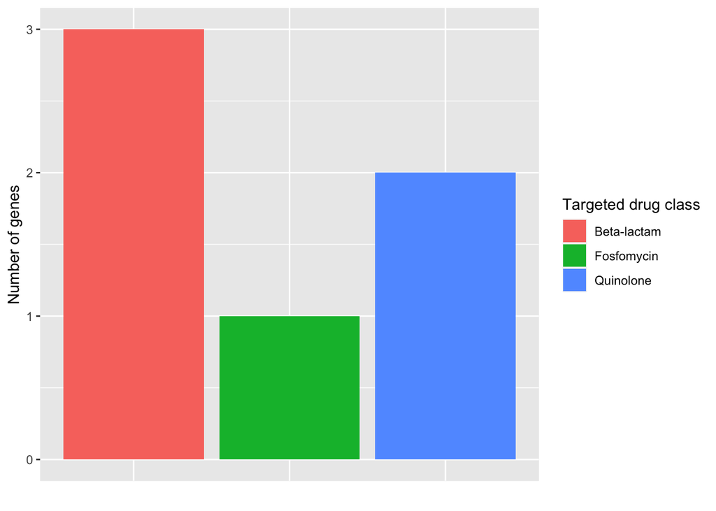

Figure 1: Resistome Predicted with Resfinder

### Point mutations

Table 3: Point mutations annotated with Resfinder

| Mutation | Nucleotide.change | Amino.acid.change | Resistance | PMID |
| --- | --- | --- | --- | --- |
| ompK36 p.N49S | AAC -> AGC | N -> S | cephalosporins | 25245001 |
| ompK36 p.L59V | CTT -> GTA | L -> V | cephalosporins | 25245001 |
| ompK37 p.I70M | ATT -> ATG | I -> M | carbapenem | 22282462 |
| ompK37 p.I128M | ATT -> ATG | I -> M | carbapenem | 22282462 |
| ompK37 p.N230G | AAC -> GGC | N -> G | carbapenem | 22282462 |

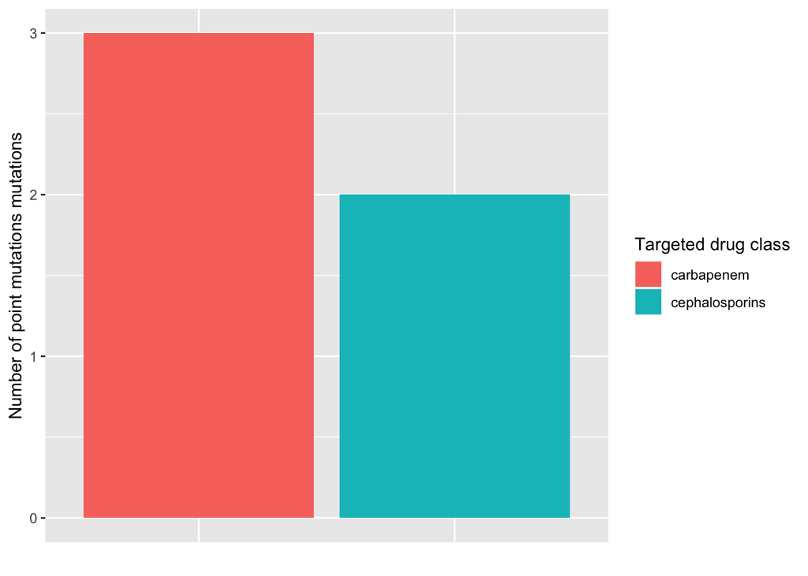

Figure 2: Resistome Predicted using Resfinder point mutations

## CARD RGI

The results obtained with RGI tool are summarized in the heatmap produced by the tool itself (Figure 3). Additionally, the annotation results are also shown in interactive table showing the complete annotation information (Table 4). They can be roughly divided into two main categories:

1. Perfect hits
   - detects perfect matches to the curated reference sequences and mutations in the CARD
2. Strict hits
   - detects previously unknown variants of known AMR genes, including secondary screen for key mutations, using detection models with CARD’s curated similarity cut-offs to ensure the detected variant is likely a functional AMR gene

> **Obs:** CARD RGI tool always tries to annotate functional AMR genes, however, depending on the assembly, a not functional gene may yet be annotated. There for, users are advised to double check genes annotated under **Strict** category.

Table 4: RGI annotation results. The perfect hits are highlighted in yellow while the strict hits in light blue.

| Prokka_ID | Product | AMR Gene Family | Drug Class | Resistance Mechanism | CVTERM.ID | Query Protein Coordinates | Cut_Off |
| --- | --- | --- | --- | --- | --- | --- | --- |
| BNHFPCLP_06867 | emrR | major facilitator superfamily (MFS) antibiotic efflux pump | fluoroquinolone antibiotic | antibiotic efflux | 36655 | contig_1_segment0:5276801-5277331 | Strict |
| BNHFPCLP_00633 | mdtC | resistance-nodulation-cell division (RND) antibiotic efflux pump | aminocoumarin antibiotic | antibiotic efflux | 37174 | contig_1_segment0:486373-489450 | Strict |
| BNHFPCLP_00628 | baeR | resistance-nodulation-cell division (RND) antibiotic efflux pump | aminoglycoside antibiotic; aminocoumarin antibiotic | antibiotic efflux | 37208 | contig_1_segment0:482763-483485 | Strict |
| BNHFPCLP_02425 | CTX-M-15 | CTX-M beta-lactamase | cephalosporin | antibiotic inactivation | 38278 | contig_1_segment0:1905397-1906272 | Strict |
| BNHFPCLP_07077 | KPC-2 | KPC beta-lactamase | monobactam; carbapenem; cephalosporin; penam | antibiotic inactivation | 38712 | contig_7_segment0:1932-2813 | Perfect |
| BNHFPCLP_04320 | FosA5 | fosfomycin thiol transferase | fosfomycin | antibiotic inactivation | 39793 | contig_1_segment0:3329719-3330180 | Strict |
| BNHFPCLP_06213 | Escherichia coli parC conferring resistance to fluoroquinolones | fluoroquinolone resistant parC | fluoroquinolone antibiotic | antibiotic target alteration | 39892 | contig_1_segment0:4770803-4772164 | Strict |
| BNHFPCLP_04861 | Escherichia coli EF-Tu mutants conferring resistance to Pulvomycin | elfamycin resistant EF-Tu | elfamycin antibiotic | antibiotic target alteration | 39953 | contig_1_segment0:3763031-3764041 | Strict |
| BNHFPCLP_05798 | Escherichia coli EF-Tu mutants conferring resistance to Pulvomycin | elfamycin resistant EF-Tu | elfamycin antibiotic | antibiotic target alteration | 39953 | contig_1_segment0:4479550-4480560 | Strict |
| BNHFPCLP_01883 | Klebsiella pneumoniae KpnE | major facilitator superfamily (MFS) antibiotic efflux pump | macrolide antibiotic; aminoglycoside antibiotic; cephalosporin; tetracycline antibiotic; peptide antibiotic; rifamycin antibiotic | antibiotic efflux | 42506 | contig_1_segment0:1487680-1488042 | Strict |

[output cut: 4 more lines]

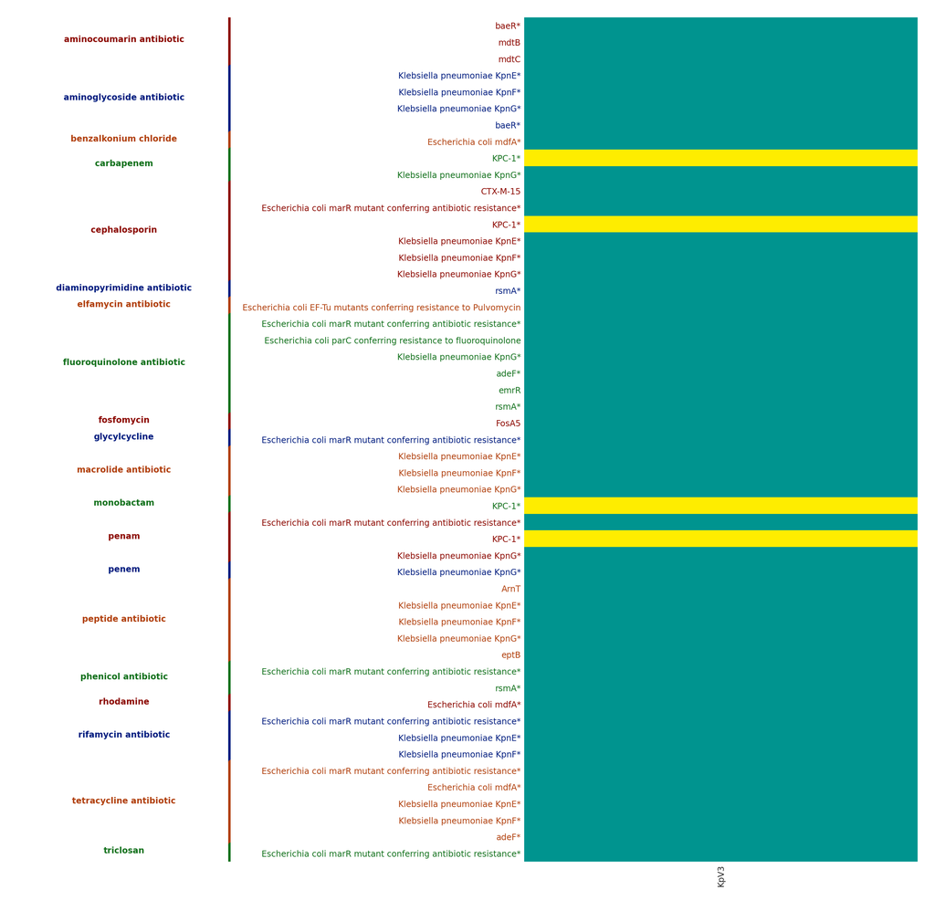

Figure 3: RGI’s phenotype prediction. AMR genes are listed in alphabetical order and unique resistome profiles are displayed with their frequency. Yellow represents a perfect hit, Blue-green represents a strict hit.

## AMRFinder

The AMRFinderPlus annotation results are summarized below in an interactive table containing the complete annotation information (Table 5) and image showing the targeted drug classes (Figure 4). Whenever possible, all feature have links to NCBI database marking the closest reference sequence to each annotated gene. The results obtained with AMRFinderPlus can be roughly divided into two main categories:

1. Genes related to antibiotics, called AMR;
2. Genes related to stress resistance which can be:
   - biocide resistance
   - metal resistance
   - heat resistance

### Acquired ARGs detected

- **AMR genes found in the query genome:**
  - bla
  - blaCTX-M
  - kdeA
  - emrD
  - blaKPC-2

### Supporting Data

Table 5: Resistance genes annotated from NCBI AMR curated database using AMRfinderplus

| Resistance type | Resistance subtype | Query protein | Gene | Product | Resistance Class | Resistance subclass | Detection method | Ref. Accession | Genomic coordinates |
| --- | --- | --- | --- | --- | --- | --- | --- | --- | --- |
| AMR | AMR | BNHFPCLP_01829 | bla | class A beta-lactamase | BETA-LACTAM | BETA-LACTAM | HMM | WP_032491601.1 | contig_1_segment0:1446666-1447337 |
| AMR | AMR | BNHFPCLP_02425 | blaCTX-M | CTX-M family class A extended-spectrum beta-lactamase | BETA-LACTAM | CEPHALOSPORIN | BLASTP | WP_000239590.1 | contig_1_segment0:1905397-1906272 |
| AMR | AMR | BNHFPCLP_02801 | kdeA | multidrug efflux MFS transporter KdeA | EFFLUX | EFFLUX | BLASTP | ABR76310.1 | contig_1_segment0:2204877-2206109 |
| AMR | AMR | BNHFPCLP_05284 | emrD | multidrug efflux MFS transporter EmrD | EFFLUX | EFFLUX | BLASTP | ACN65732.1 | contig_1_segment0:4079473-4080657 |
| AMR | AMR | BNHFPCLP_07077 | blaKPC-2 | carbapenem-hydrolyzing class A beta-lactamase KPC-2 | BETA-LACTAM | CARBAPENEM | ALLELEP | WP_004199234.1 | contig_7_segment0:1932-2813 |
| STRESS | METAL | BNHFPCLP_05091 | fieF | CDF family cation-efflux transporter FieF |  |  | BLASTP | BAB89353.1 | contig_1_segment0:3934605-3935507 |
| STRESS | METAL | BNHFPCLP_06478 | arsC | glutaredoxin-dependent arsenate reductase | ARSENIC | ARSENATE | HMM | AAA21096.1 | contig_1_segment0:4985839-4986261 |

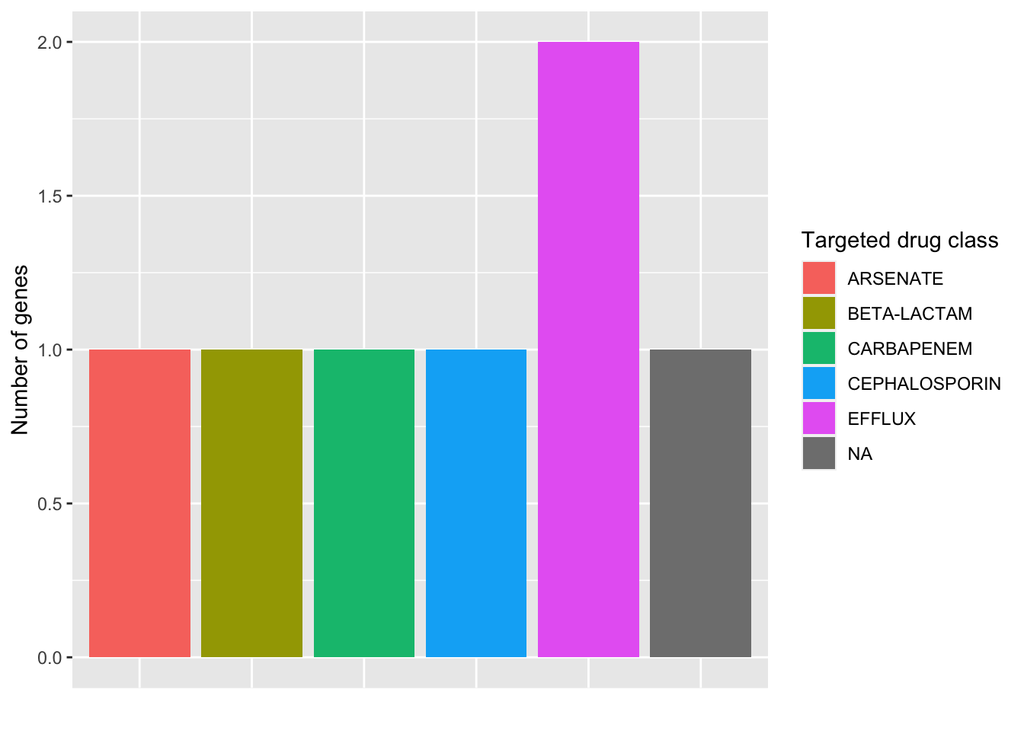

Figure 4: Resistome Predicted using NCBI’s AMRFinderplus

## ARGminer

ARGminer is an online resource for the inspection and curation of ARGs based on crowdsourcing as well as a platform to promote interaction and collaboration for the ARG scientific community. We put this database here in the report and annotation in order to support the initative and to help it go towards nomenclature simplification. Genes are scanned via `BLASTp` since ARGminer is a protein database. This alignment is summarized in table 6.

> It must be used with caution. Remender, it is a super new database thus it is rapidly changing and may yet contain errors.

### BLAST summary

Table 6: Resistance genes detected using ARGminer database via BLASTp

| Protein ID | Start | End | Strand | Gene Name | Coverage Map | Gaps | Coverage % | Identity % | Reference | Drug target |
| --- | --- | --- | --- | --- | --- | --- | --- | --- | --- | --- |
| BNHFPCLP_00509 | 1 | 398 | + | Bcr | 1-398/398 | 0/0 | 100 | 99.5 | BAH64410 | multidrug |
| BNHFPCLP_00628 | 1 | 239 | + | baeR | 1-239/240 | 0/0 | 99.58 | 92.1 | YP_490321.1 | multidrug |
| BNHFPCLP_00633 | 1 | 1025 | + | mdtC | 1-1025/1025 | 0/0 | 100 | 90.8 | NC_002695.1.916586.p01 | aminocoumarin |
| BNHFPCLP_01056 | 1 | 135 | + | H-NS | 1-135/137 | 0/0 | 98.54 | 91.1 | CP001918.1.gene1661.p01 | macrolide;fluoroquinolone;cephalosporin;cephamycin;penam;tetracycline |
| BNHFPCLP_01829 | 1 | 223 | + | SHV-187 | 43-265/265 | 0/0 | 84.15 | 99.1 | S00464 | beta_lactam |
| BNHFPCLP_02425 | 1 | 291 | + | CTX-M-15 | 1-291/291 | 0/0 | 100 | 99.3 | AAL02127.1 | beta_lactam |
| BNHFPCLP_02535 | 1 | 402 | + | MdtH | 56-457/457 | 0/0 | 87.96 | 99 | BAH62779 | multidrug |
| BNHFPCLP_02681 | 6 | 187 | + | Klebsiella pneumoniae OmpK35 | 2-183/227 | 0/0 | 80.18 | 98.9 | YP_005226137.1 | monobactam;carbapenem;cephalosporin;cephamycin;penam;penem |
| BNHFPCLP_02753 | 1 | 371 | + | macA | 1-371/371 | 0/0 | 100 | 99.5 | CP000647.1.gene911.p01 | macrolide |
| BNHFPCLP_02801 | 1 | 410 | + | Escherichia coli mdfA | 1-410/410 | 0/0 | 100 | 99.8 | YP_001334540 | tetracycline;benzalkoniumchloride;rhodamine |

[output cut: 9 more lines]

## Prokka

Additionally, Prokka generically annotates a few proteins that are related to any type of resistance. One must take caution when evaluating this result because this annotation can be very generic and therefore not so meaningful. Because it uses hmms, sometimes the annotation of genes can be based on a single detected motif thus its results must be checked whether they are correctly annotated and/or functional. These are showed in Table 7.

Table 7: Generic annotation of resistance determinants by Prokka

| Contig | Start | End | Description |
| --- | --- | --- | --- |
| contig_1_segment0 | 147662 | 148441 | ID=BNHFPCLP_00188;Name=mexB_1;db_xref=COG:COG0841;gene=mexB_1;inference=ab initio prediction:Prodigal:002006,similar to AA sequence:UniProtKB:P52002;locus_tag=BNHFPCLP_00188;product=Multidrug resistan… |
| contig_1_segment0 | 385040 | 386236 | ID=BNHFPCLP_00509;Name=bcr;gene=bcr;inference=ab initio prediction:Prodigal:002006,similar to AA sequence:UniProtKB:P28246;locus_tag=BNHFPCLP_00509;product=Bicyclomycin resistance protein |
| contig_1_segment0 | 482763 | 483485 | ID=BNHFPCLP_00628;Name=baeR;db_xref=COG:COG0745;gene=baeR;inference=ab initio prediction:Prodigal:002006,similar to AA sequence:UniProtKB:P69228;locus_tag=BNHFPCLP_00628;product=Transcriptional regula… |
| contig_1_segment0 | 484956 | 485126 | ID=BNHFPCLP_00631;Name=mdtD_1;gene=mdtD_1;inference=ab initio prediction:Prodigal:002006,similar to AA sequence:UniProtKB:P36554;locus_tag=BNHFPCLP_00631;product=Putative multidrug resistance protein … |
| contig_1_segment0 | 485277 | 486371 | ID=BNHFPCLP_00632;Name=mdtD_2;gene=mdtD_2;inference=ab initio prediction:Prodigal:002006,similar to AA sequence:UniProtKB:P36554;locus_tag=BNHFPCLP_00632;product=Putative multidrug resistance protein … |
| contig_1_segment0 | 486373 | 489450 | ID=BNHFPCLP_00633;Name=mdtC;gene=mdtC;inference=ab initio prediction:Prodigal:002006,similar to AA sequence:UniProtKB:B5YUD4;locus_tag=BNHFPCLP_00633;product=Multidrug resistance protein MdtC;Addition… |
| contig_1_segment0 | 489451 | 492573 | ID=BNHFPCLP_00634;Name=mdtB_1;gene=mdtB_1;inference=ab initio prediction:Prodigal:002006,similar to AA sequence:UniProtKB:Q1R9Z6;locus_tag=BNHFPCLP_00634;product=Multidrug resistance protein MdtB |
| contig_1_segment0 | 492573 | 493073 | ID=BNHFPCLP_00635;Name=mdtA_1;gene=mdtA_1;inference=ab initio prediction:Prodigal:002006,similar to AA sequence:UniProtKB:P76397;locus_tag=BNHFPCLP_00635;product=Multidrug resistance protein MdtA |
| contig_1_segment0 | 493039 | 493812 | ID=BNHFPCLP_00636;Name=mdtA_2;gene=mdtA_2;inference=ab initio prediction:Prodigal:002006,protein motif:HAMAP:MF_01422;locus_tag=BNHFPCLP_00636;product=Multidrug resistance protein MdtA |
| contig_1_segment0 | 895437 | 896669 | ID=BNHFPCLP_01125;Name=mdtH_1;gene=mdtH_1;inference=ab initio prediction:Prodigal:002006,similar to AA sequence:UniProtKB:P69367;locus_tag=BNHFPCLP_01125;product=Multidrug resistance protein MdtH |

[output cut: 61 more lines]